# AnalisisExploratorio

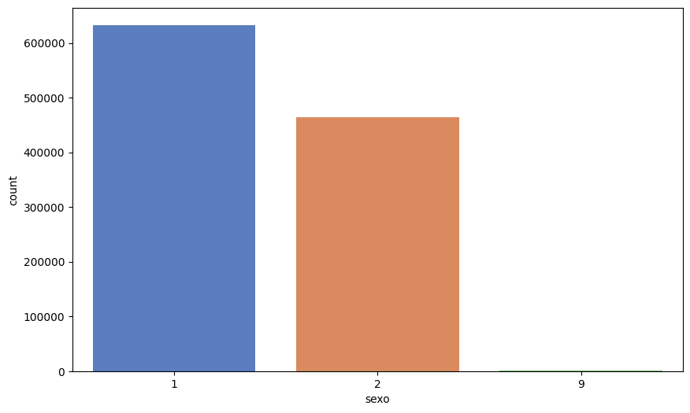

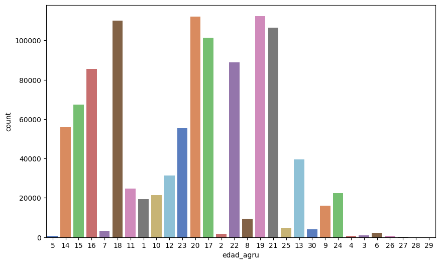

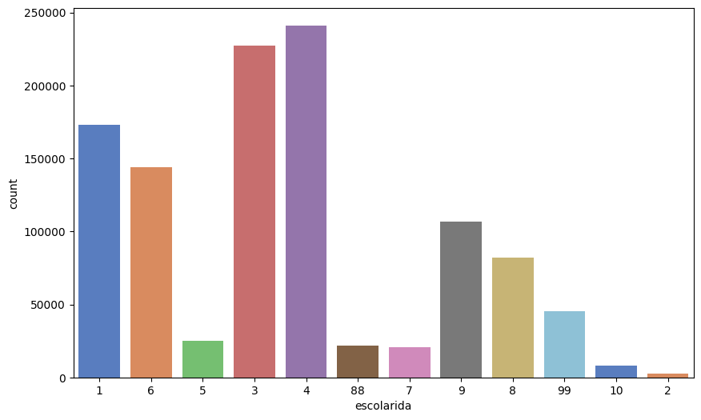

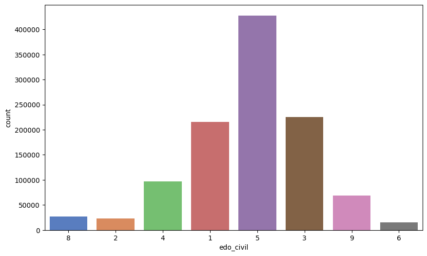

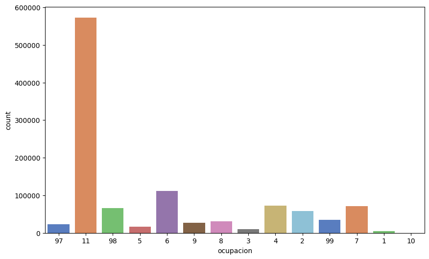

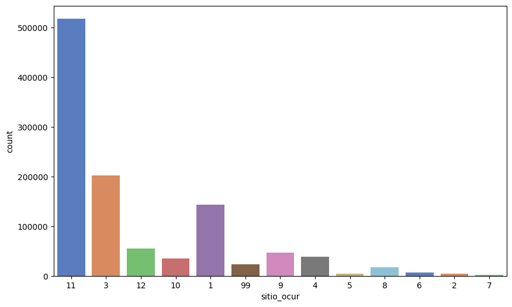

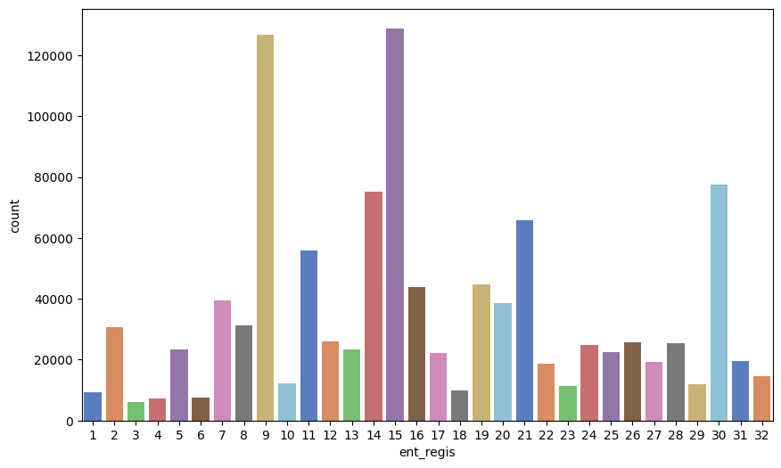

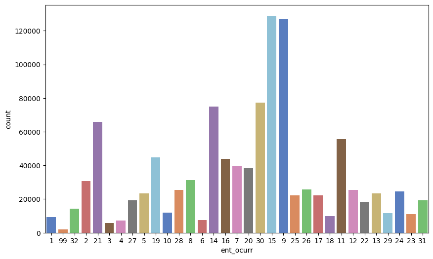

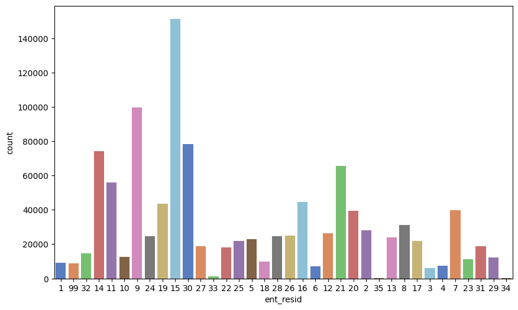

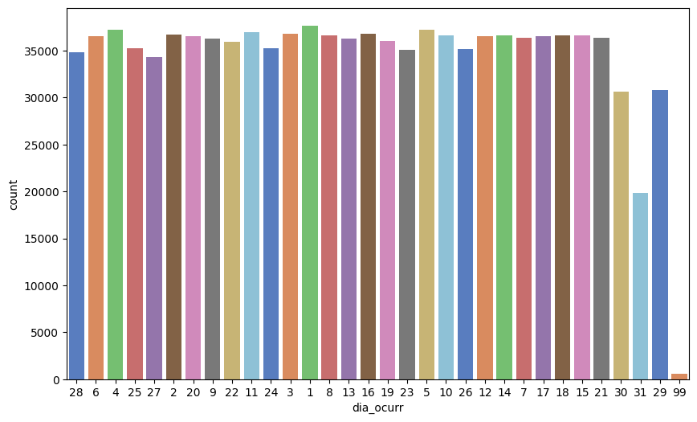

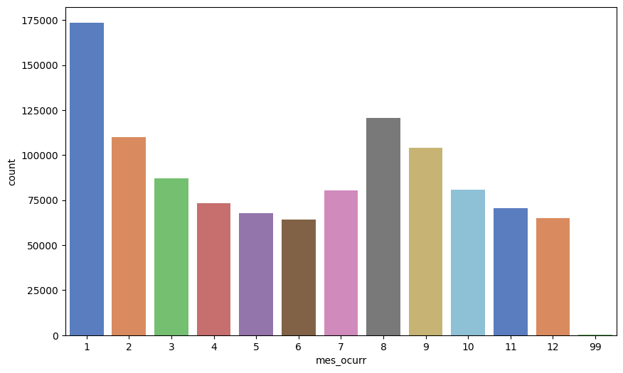

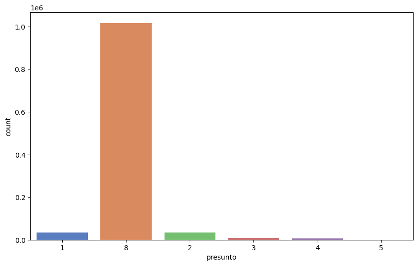

[2 more figures not shown]

```python
#Ahora se hace un countplot de las variables

for col in interest_columns:
    if ((col == "edad") or (col == "causa_def") or (col == 'anio_ocur')):
        continue
    plt.figure(figsize=(10, 6))
    sns.countplot(data=data, x=col, palette="muted")
    plt.show()
```

```python
#Porcentaje de personas con sexo hombre (1)
hombres = data[data["sexo"] ==  '1']
porcentaje_hombres = ((hombres.shape[0])/(data.shape[0]))*100

porcentaje_hombres
```

```
57.63711405161245
```

```python
#Porcentaje de personas que fallecen en Enero (1)
enero = data[data["mes_ocurr"] ==  '1']
porcentaje_enero = ((enero.shape[0])/(data.shape[0]))*100

porcentaje_enero
```

```
15.809054166389725
```

```python
#Promedio de porcentaje que fallecen por mes
meses = list(range(1, 13))

sum_porcentajes = 0

for i in meses:
    mes_df = data[data["mes_ocurr"] == str(i)]
    sum_porcentajes += (mes_df.shape[0])/(data.shape[0])

porcentaje_promedio_mes = (sum_porcentajes/12)*100

porcentaje_promedio_mes
```

```
8.330912928240982
```

De las gráficas anteriores se pueden obtener diferentes conclusiones.

En primer lugar se cae en una falsedad al decir que por ejemplo de la gráfica de estado civil, la concentración esta en el valor de 5. el cuál corresponde con casado (a) y tal vez se podría pensar que si eres casado tienes más probabilidades de morir, pero esto tiene otra explicación y es que si vemos los datos la cantidad de personas fallecidas de más de 60 años es mucho mayor a las de menos de 60 y esto tiene que ver con que entre mas grande seas mas probable es que tu estado civil sea casado. Este mismo efecto sucede en las gráficas de área urbana o rural, de nivel educativo, entidad y ocupación.

Aunque un efecto muy interesante es que una gran parte, siendo concretos, del 100% de las personas fallecidas, un 57.63% son hombres. Además el mes en el que mas muertes ocurren es Enero con un 15.8% del total de muertes cuando el promedio por mes es del 8.33%.

Para analizar de manera correcta las variables de **presunto agresor** y de **presunta defunción violenta** hay que eliminar aquellos datos que no hayan ocurrido en estas circunstancias.

```python
data_presunto = data[data["presunto"] != str(8)]

data_presunto
```

|  | sexo | edad | edad_agru | escolarida | edo_civil | ocupacion | sitio_ocur | causa_def | ent_regis | ent_ocurr | ent_resid | dia_ocurr | mes_ocurr | anio_ocur | presunto | par_agre | area_ur |
| --- | --- | --- | --- | --- | --- | --- | --- | --- | --- | --- | --- | --- | --- | --- | --- | --- | --- |
| 40 | 1 | 4004 | 5 | 1 | 8 | 97 | 11 | X470 | 1 | 1 | 1 | 28 | 1 | 2021 | 1 | 88 | 1 |
| 42 | 1 | 4045 | 14 | 6 | 4 | 98 | 3 | V892 | 1 | 1 | 1 | 4 | 1 | 2021 | 1 | 88 | 2 |
| 44 | 2 | 4059 | 16 | 3 | 1 | 5 | 3 | V892 | 1 | 1 | 1 | 27 | 1 | 2021 | 1 | 88 | 1 |
| 45 | 1 | 4047 | 14 | 6 | 1 | 6 | 10 | V892 | 1 | 1 | 1 | 27 | 1 | 2021 | 1 | 88 | 1 |
| 46 | 1 | 4013 | 7 | 4 | 1 | 11 | 12 | X470 | 1 | 1 | 1 | 28 | 1 | 2021 | 1 | 88 | 1 |
| ... | ... | ... | ... | ... | ... | ... | ... | ... | ... | ... | ... | ... | ... | ... | ... | ... | ... |
| 1122213 | 2 | 4045 | 14 | 4 | 4 | 98 | 10 | X954 | 32 | 32 | 32 | 30 | 12 | 2021 | 2 | 99 | 1 |
| 1122214 | 1 | 4034 | 11 | 6 | 4 | 98 | 12 | X957 | 32 | 32 | 32 | 1 | 12 | 2021 | 2 | 99 | 1 |
| 1122215 | 2 | 4039 | 12 | 6 | 5 | 11 | 10 | X954 | 32 | 32 | 32 | 30 | 12 | 2021 | 2 | 99 | 1 |
| 1122216 | 1 | 4029 | 10 | 6 | 1 | 9 | 10 | X954 | 32 | 32 | 7 | 30 | 12 | 2021 | 2 | 99 | 2 |
| 1122217 | 1 | 4042 | 13 | 6 | 4 | 9 | 10 | X955 | 32 | 32 | 32 | 31 | 12 | 2021 | 2 | 99 | 1 |

81783 rows × 17 columns

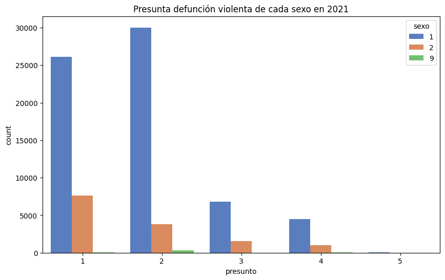

```python
plt.figure(figsize=(10, 6))
plt.title("Presunta defunción violenta de cada sexo en 2021")
sns.countplot(data=data_presunto, x="presunto", palette="muted", hue="sexo")
plt.show()
```

```python
accidente = data_presunto[data_presunto["presunto"] ==  '1']
accidente_n = accidente.shape[0]


homicidio = data_presunto[data_presunto["presunto"] ==  '2']
homicidio_n = homicidio.shape[0]


print("Accidente:", accidente_n)
print("Homicidio:", homicidio_n)
```

```
Accidente: 33745
Homicidio: 34173
```

Los datos nos dicen que 33745 personas murieron por accidente (1) y alrededor de otras 34173 (2) fueron homicidios.

Además los datos nos muestran que por una gran mayoría los hombres tienden a tener más accidentes, tener mayor número de homicidios así como más suicidios.

Ahora para analizar quienes son los agresores, tenemos que eliminar aquellos valores que no nos sirvan.

- 99: No especificado
- 88: No aplica

```python
data_presunto_agresor = data_presunto[(data_presunto["par_agre"] != str(88)) & (data["par_agre"] != str(99))]

data_presunto_agresor
```

|  | sexo | edad | edad_agru | escolarida | edo_civil | ocupacion | sitio_ocur | causa_def | ent_regis | ent_ocurr | ent_resid | dia_ocurr | mes_ocurr | anio_ocur | presunto | par_agre | area_ur |
| --- | --- | --- | --- | --- | --- | --- | --- | --- | --- | --- | --- | --- | --- | --- | --- | --- | --- |
| 44541 | 2 | 4048 | 14 | 6 | 4 | 5 | 3 | X970 | 3 | 3 | 3 | 19 | 11 | 2021 | 2 | 11 | 1 |
| 61646 | 1 | 4044 | 13 | 4 | 9 | 7 | 11 | X990 | 5 | 5 | 5 | 26 | 6 | 2021 | 2 | 39 | 1 |
| 70398 | 1 | 4031 | 11 | 9 | 1 | 11 | 10 | Y004 | 5 | 5 | 5 | 4 | 7 | 2021 | 2 | 68 | 1 |
| 77581 | 1 | 4028 | 10 | 6 | 9 | 11 | 10 | X994 | 5 | 5 | 5 | 18 | 4 | 2021 | 2 | 72 | 1 |
| 86633 | 1 | 4003 | 4 | 2 | 8 | 97 | 1 | Y078 | 6 | 6 | 6 | 2 | 10 | 2021 | 2 | 37 | 1 |
| ... | ... | ... | ... | ... | ... | ... | ... | ... | ... | ... | ... | ... | ... | ... | ... | ... | ... |
| 1102106 | 1 | 4026 | 10 | 3 | 4 | 98 | 11 | X990 | 31 | 31 | 31 | 5 | 3 | 2021 | 2 | 46 | 1 |
| 1110179 | 2 | 3007 | 1 | 88 | 8 | 97 | 12 | Y098 | 32 | 32 | 32 | 99 | 5 | 2021 | 2 | 1 | 1 |
| 1111865 | 2 | 4049 | 14 | 6 | 4 | 11 | 1 | X918 | 32 | 32 | 32 | 3 | 9 | 2021 | 2 | 3 | 2 |
| 1120460 | 2 | 4067 | 18 | 6 | 5 | 11 | 11 | Y000 | 32 | 32 | 32 | 17 | 10 | 2021 | 2 | 5 | 2 |
| 1120536 | 1 | 4067 | 18 | 3 | 5 | 6 | 11 | Y000 | 32 | 32 | 32 | 17 | 10 | 2021 | 2 | 5 | 2 |

185 rows × 17 columns

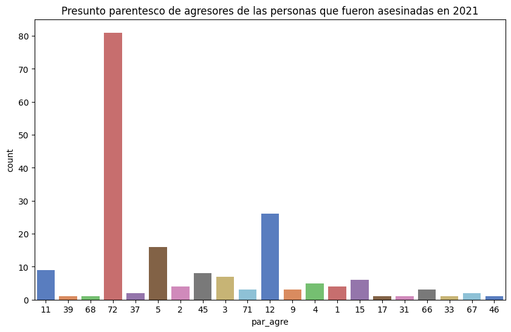

```python
plt.figure(figsize=(10, 6))
plt.title("Presunto parentesco de agresores de las personas que fueron asesinadas en 2021")
sns.countplot(data=data_presunto_agresor, x="par_agre", palette="muted")
plt.show()
```